```python
from IPython.display import HTML

HTML('''<script>
code_show=true;
function code_toggle() {
 if (code_show){
 $('div.input').hide();
 } else {
 $('div.input').show();
 }
 code_show = !code_show
}
$( document ).ready(code_toggle);
</script>
<form action="javascript:code_toggle()"><input type="submit" value="Click here to toggle on/off the raw code."></form>''')
```

# BREAST CANCER PREDICTION PROJECT

In this project, I will make use of measurements of cell nucleus from a breast mass to classify the mass as benign or malignant breast cancer. The data set was obtained from the kaggle website. Also can be found on UCI Machine Learning Repository: https://archive.ics.uci.edu/ml/datasets/Breast+Cancer+Wisconsin+%28Diagnostic%29.

Features Description:

- id : ID number
- Diagnosis: (M = malignant, B = benign)
- columns 3-32: measurements of cell nucleus

Ten real-valued features computed for each cell nucleus:

a) radius (mean of distances from center to points on the perimeter) b) texture (standard deviation of gray-scale values) c) perimeter d) area e) smoothness (local variation in radius lengths) f) compactness (perimeter^2 / area - 1.0) g) concavity (severity of concave portions of the contour) h) concave points (number of concave portions of the contour) i) symmetry j) fractal dimension ("coastline approximation" - 1)

The mean, standard error and "worst" or largest (mean of the three largest values) of these features were computed for each image, resulting in 30 features. For instance, field 3 is Mean Radius, field 13 is Radius SE, field 23 is Worst Radius.

The dataset is comprised of 569 observations, and 32 columns.

## LOAD REQUIRED PACKAGES

I loaded the required packages for this project.

```python
## Load the required packages
import pandas as pd
import numpy as np
from sklearn.model_selection import train_test_split
from sklearn import preprocessing
from sklearn.preprocessing import StandardScaler
import matplotlib.pyplot as plt
import seaborn.apionly as sns
from pandas.tools.plotting import scatter_matrix
from sklearn.linear_model import LogisticRegression
from sklearn.svm import SVC
from sklearn.ensemble import RandomForestClassifier
from sklearn.ensemble import GradientBoostingClassifier
from sklearn.model_selection import learning_curve
from sklearn import metrics
from sklearn.metrics import accuracy_score
from sklearn.metrics import f1_score
from sklearn.metrics import auc
from sklearn.metrics import classification_report
from sklearn.metrics import confusion_matrix
% matplotlib inline
import warnings
warnings.filterwarnings('ignore')
```

## LOAD AND SPLIT DATASET TO TRAINING, VALIDATION AND TESTING SET

I loaded in the data set, and split it into training, validation and testing set.

[output not shown]

```python
## Read in data
pd.set_option('display.max_columns' , 40)
breast_cancer = pd.read_csv('/.../Datasets/breast_cancer.csv')
```

```python
## Split the dataset to training, validation and testing set
train, test = train_test_split(breast_cancer, test_size = 0.2, random_state = 189)
training, val = train_test_split(train, test_size = 0.25, random_state = 189)
```

## EXPLORATORY ANALYSIS

I performed label encoding on the diagnosis column. The codes are:

```
    - Benign - 0
    - Malignant - 1
```

Since the id column is just an identifier, I will be of no use in the classification model.

The table below gives a statistic summary of the data. Based on the data summary, I decided to remove the Unnamed: 32 columns since it is empty.

```python
## Encode the diagnosis column
le = preprocessing.LabelEncoder()
le.fit(training['diagnosis'])
training['diagnosis'] = le.transform(training['diagnosis'])
```

```python
## remove identifier column
training = training.drop('id',1)
```

```python
## shoe statistic summary of the data
print(training.describe())
```

```
        diagnosis  radius_mean  texture_mean  perimeter_mean    area_mean  \
count  341.000000   341.000000    341.000000      341.000000   341.000000
mean     0.357771    14.151569     19.069912       92.185660   659.995308
std      0.480049     3.661032      4.339867       25.375319   374.491672
min      0.000000     6.981000     10.380000       43.790000   143.500000
25%      0.000000    11.710000     16.020000       75.460000   420.500000
50%      0.000000    13.370000     18.580000       85.980000   551.700000
75%      1.000000    15.700000     21.800000      102.500000   758.600000
max      1.000000    28.110000     39.280000      188.500000  2501.000000

       smoothness_mean  compactness_mean  concavity_mean  concave points_mean  \
count       341.000000        341.000000      341.000000           341.000000
mean          0.096508          0.105365        0.090991             0.049893
std           0.014356          0.054440        0.085227             0.040736
min           0.062510          0.019380        0.000000             0.000000
25%           0.086000          0.063300        0.029950             0.020700
50%           0.094950          0.093620        0.061540             0.033840
75%           0.106300          0.130600        0.126700             0.069870
max           0.163400          0.345400        0.426800             0.201200

       symmetry_mean  fractal_dimension_mean   radius_se  texture_se  \
count     341.000000              341.000000  341.000000  341.000000
mean        0.181576                0.062941    0.406693    1.197705
std         0.028640                0.007323    0.301939    0.519390
min         0.116700                0.049960    0.111500    0.412500
25%         0.161900                0.057700    0.227100    0.833900
50%         0.179200                0.061470    0.313500    1.095000
75%         0.196600                0.066210    0.472700    1.398000
max         0.304000                0.095750    2.873000    3.647000

       perimeter_se     area_se  smoothness_se  compactness_se  concavity_se  \
count    341.000000  341.000000     341.000000      341.000000    341.000000
mean       2.908615   41.626261       0.007187        0.026491      0.033590
std        2.265144   52.844852       0.003267        0.019570      0.035418
min        0.921900    7.228000       0.002667        0.002252      0.000000
25%        1.572000   17.720000       0.005298        0.012630      0.015140
50%        2.225000   24.250000       0.006383        0.021140      0.025720
75%        3.218000   43.520000       0.008312        0.032950      0.042660
max       21.980000  542.200000       0.031130        0.135400      0.396000

```

[output cut: 24 more lines]

```
min             0.034320         0.000000              0.000000
25%             0.147800         0.120600              0.064980
50%             0.210100         0.224100              0.100100
75%             0.337100         0.379600              0.159900
max             1.058000         1.252000              0.291000

       symmetry_worst  fractal_dimension_worst  Unnamed: 32
count      341.000000               341.000000          0.0
mean         0.289807                 0.083979          NaN
std          0.061198                 0.017885          NaN
min          0.160300                 0.055250          NaN
25%          0.251300                 0.071910          NaN
50%          0.281200                 0.080060          NaN
75%          0.317600                 0.091850          NaN
max          0.555800                 0.207500          NaN
```

```python
## remove empty column
training = training.drop('Unnamed: 32',1)
```

### Correlation Matrix

Below is a correlation matrix of the data

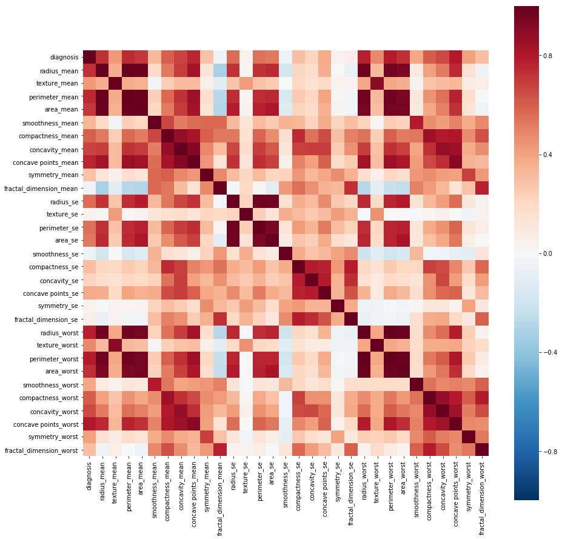

```python
# calculate the correlation matrix
corr = training.corr()

# plot the heatmap
fig, ax = plt.subplots(figsize=(15,15))
sns.heatmap(corr, cbar = True, square = True, annot = False,
           xticklabels = corr.columns.values,
           yticklabels = corr.columns.values, ax = ax)

plt.show()
```

As seen in the correlation matrix above, the following features has near-zero correlation with diagnosis and will not be used in the classification model:

```
- fractal_dimension_mean, texture_se, smoothness_se, symmetry_se, and fractal_dimension_se.
```

Also, the following groups of features are highly correlated with each other.

```
- radius mean, perimeter mean, area mean, radius worst, perimeter worst, area worst
- texture mean, texture worst
- concavity mean, concave points mean, concave points worst
- radius se, perimeter se, area se
```

To resolve the multicollinearity, I chose one variable from each group that had the highest correlation with diagnosis. The correlation table shows the correlation each of the colinear variables has with diagnosis. I chose the following features from each group to be included in the classification model, and dropped the other features in the groups:

```
 - perimeter worst
 - texture worst
 - concave points worst
 - radius se
```

### correlation table of features with multicolinearity

```python
multicollinear_features = ['radius_mean', 'perimeter_mean', 'area_mean', 'radius_worst', 'perimeter_worst', 'area_worst',
                          'texture_mean', 'texture_worst', 'concavity_mean', 'concave points_mean', 'concave points_worst',
                          'radius_se', 'perimeter_se', 'area_se', 'diagnosis']
multicollinear = training[multicollinear_features]
target_cols = ['diagnosis']
corr2 = round(multicollinear.corr().filter(target_cols).drop(target_cols),3)
print(corr2)
```

```
                      diagnosis
radius_mean               0.734
perimeter_mean            0.744
area_mean                 0.707
radius_worst              0.780
perimeter_worst           0.785
area_worst                0.732
texture_mean              0.432
texture_worst             0.478
concavity_mean            0.677
concave points_mean       0.764
concave points_worst      0.798
radius_se                 0.561
perimeter_se              0.553
area_se                   0.526
```

```python
## Remove variables with near-zero correlation with the target 'diagnosis'
training = training.drop(['fractal_dimension_mean', 'texture_se', 'smoothness_se', 'symmetry_se', 'fractal_dimension_se'],1)

## Resolve multicollinearity
training = training.drop(['radius_mean', 'perimeter_mean', 'area_mean', 'radius_worst', 'area_worst', 'texture_mean',
                         'concavity_mean', 'concave points_mean', 'perimeter_se', 'area_se'],1)
```

### Visualizing the data

I used the scatter plot below of the two highest correlated features to visualize the data.

The classes are well separated except for the region of intersection when concave points worst is betwee 0.1 and 0.2 while perimeter worst is between 100 and 125. Based on this, it will be unrealistic to expect a perfect classification accuracy sore.

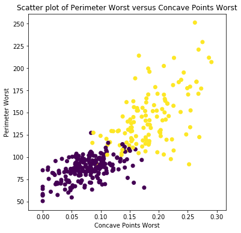

```python
fig = plt.figure(figsize=(20, 6))
ax = fig.add_subplot(131)
ax.scatter(training['concave points_worst'],y = training['perimeter_worst'], c = training['diagnosis'])
ax.set_xlabel('Concave Points Worst')
ax.set_ylabel('Perimeter Worst')
ax.set_title('Scatter plot of Perimeter Worst versus Concave Points Worst')
plt.show()
```

## CLEANING THE DATA

First I cleaned the validation and testing set to match the training set, by dropping the columns that were not required. Then I defined the x and y features in all the datasets.

```python
## Label encode diagnosis is in validation and testing set
val['diagnosis'] = le.transform(val['diagnosis'])
test['diagnosis'] = le.transform(test['diagnosis'])


## Drop unrequired features in validation and testing set
val = val.drop(['id', 'Unnamed: 32'],1)
test = test.drop(['id', 'Unnamed: 32'],1)
## Remove variables with near-zero correlation with the target 'diagnosis'
val = val.drop(['fractal_dimension_mean', 'texture_se', 'smoothness_se', 'symmetry_se', 'fractal_dimension_se'],1)
test = test.drop(['fractal_dimension_mean', 'texture_se', 'smoothness_se', 'symmetry_se', 'fractal_dimension_se'],1)
## Resolve multicollinearity
val = val.drop(['radius_mean', 'perimeter_mean', 'area_mean', 'radius_worst', 'area_worst', 'texture_mean',
                         'concavity_mean', 'concave points_mean', 'perimeter_se', 'area_se'],1)
test = test.drop(['radius_mean', 'perimeter_mean', 'area_mean', 'radius_worst', 'area_worst', 'texture_mean',
                         'concavity_mean', 'concave points_mean', 'perimeter_se', 'area_se'],1)
```

```python
training_X = training.drop('diagnosis',1)
training_y = training['diagnosis']
val_X = val.drop('diagnosis',1)
val_y = val['diagnosis']
test_X = test.drop('diagnosis',1)
test_y = test['diagnosis']
```

### Feature Scaling

As seen in the statistic summary of the training data, the values of the predictors are of different orders of magnitude. To prevent bias of the algorithms to any particular predictor, I have standardized all the predictors, by fitting a standardscaler to the training set, and applying it to the validation and testing set.

```python
## perform feature scaling
predictors = training_X.columns.values.tolist()
scaler = StandardScaler()
scaler.fit(training_X)
training_X = pd.DataFrame(scaler.transform(training_X), columns = predictors)
val_X = pd.DataFrame(scaler.transform(val_X), columns = predictors)
data_X = training_X.append(val_X)
data_y = training_y.append(val_y)

test_X = pd.DataFrame(scaler.transform(test_X), columns = predictors)
```

## BUILDING CLASSIFICATION MODELS

I built 3 classification models:

```
- LogR - Logistic Regression Model
- SVC_model - Support Vector Classification Model
- RF - Random Forest Classifier Model
```

The learning curves are shown below:

```python
## Logistic Regression Model
LogR = LogisticRegression(penalty='l2', C=1, fit_intercept=True, random_state=123, solver='liblinear')
LogR.fit(training_X, training_y)

def plot_curve_LogR():
    # instantiate
    LogR = LogisticRegression(penalty='l2', C=1, fit_intercept=True, random_state=123, solver='liblinear')

    # fit
    X = data_X
    y = data_y
    LogR.fit(X, y)


    train_sizes, train_err, val_err = learning_curve(LogR, X, y, n_jobs=1, cv=10, train_sizes=np.linspace(.1, 1.0, 5), verbose=0,
                                                    scoring = "neg_mean_squared_error")

    train_err = abs(train_err)**0.5
    val_err = abs(val_err)**0.5


    train_error_mean = np.mean(train_err, axis=1)
    train_error_std = np.std(train_err, axis=1)
    val_error_mean = np.mean(val_err, axis=1)
    val_error_std = np.std(val_err, axis=1)

    plt.figure()
    plt.title("Logistic Regression Model")

    # plot the std deviation as a transparent range at each training set size
    plt.fill_between(train_sizes, train_error_mean - train_error_std, train_error_mean + train_error_std, alpha=0.1, color="r")
    plt.fill_between(train_sizes, val_error_mean - val_error_std, val_error_mean + val_error_std, alpha=0.1, color="g")

    # plot the average training and test score lines at each training set size
    plt.plot(train_sizes, train_error_mean, 'o-', color="r", label="Training RMSE")
    plt.plot(train_sizes, val_error_mean, 'o-', color="g", label="Cross-validation RMSE")
    plt.legend(loc='lower right')
    plt.xlabel("Training examples")
    plt.ylabel("Root Mean Squared Error")


    # box-like grid
    plt.grid()
    # sizes the window for readability and displays the plot
    # shows error from 0 to 1.1

    plt.show()
```

```python
## Support Vector Classification
SVC_model = SVC(C=1, kernel='linear', random_state=123, probability = True)
SVC_model.fit(training_X, training_y)

def plot_curve_SVC():
    # instantiate
    SVC_model = SVC(C=1, kernel='linear', random_state=123, probability = True)

    # fit
    X = data_X
    y = data_y
    SVC_model.fit(X, y)


    train_sizes, train_err, val_err = learning_curve(SVC_model, X, y, n_jobs=1, cv=10, train_sizes=np.linspace(.1, 1.0, 5), verbose=0,
                                                    scoring = "neg_mean_squared_error")

    train_err = abs(train_err)**0.5
    val_err = abs(val_err)**0.5


    train_error_mean = np.mean(train_err, axis=1)
    train_error_std = np.std(train_err, axis=1)
    val_error_mean = np.mean(val_err, axis=1)
    val_error_std = np.std(val_err, axis=1)

    plt.figure()
    plt.title("Support Vector Classification")

    # plot the std deviation as a transparent range at each training set size
    plt.fill_between(train_sizes, train_error_mean - train_error_std, train_error_mean + train_error_std, alpha=0.1, color="r")
    plt.fill_between(train_sizes, val_error_mean - val_error_std, val_error_mean + val_error_std, alpha=0.1, color="g")

    # plot the average training and test score lines at each training set size
    plt.plot(train_sizes, train_error_mean, 'o-', color="r", label="Training RMSE")
    plt.plot(train_sizes, val_error_mean, 'o-', color="g", label="Cross-validation RMSE")
    plt.legend(loc='lower right')
    plt.xlabel("Training examples")
    plt.ylabel("Root Mean Squared Error")


    # box-like grid
    plt.grid()
    # sizes the window for readability and displays the plot
    # shows error from 0 to 1.1

    plt.show()
```

```python
## Random Forest Classification
RF = RandomForestClassifier(n_estimators=100, criterion='gini', max_depth=2, random_state=123)
RF.fit(training_X, training_y)

def plot_curve_RF():
    # instantiate
    RF = RandomForestClassifier(n_estimators=100, criterion='gini', max_depth=2, random_state=123)

    # fit
    X = data_X
    y = data_y
    RF.fit(X, y)


    train_sizes, train_err, val_err = learning_curve(RF, X, y, n_jobs=1, cv=10, train_sizes=np.linspace(.1, 1.0, 5), verbose=0,
                                                    scoring = "neg_mean_squared_error")

    train_err = abs(train_err)**0.5
    val_err = abs(val_err)**0.5


    train_error_mean = np.mean(train_err, axis=1)
    train_error_std = np.std(train_err, axis=1)
    val_error_mean = np.mean(val_err, axis=1)
    val_error_std = np.std(val_err, axis=1)

    plt.figure()
    plt.title("Random Forest Classification")

    # plot the std deviation as a transparent range at each training set size
    plt.fill_between(train_sizes, train_error_mean - train_error_std, train_error_mean + train_error_std, alpha=0.1, color="r")
    plt.fill_between(train_sizes, val_error_mean - val_error_std, val_error_mean + val_error_std, alpha=0.1, color="g")

    # plot the average training and test score lines at each training set size
    plt.plot(train_sizes, train_error_mean, 'o-', color="r", label="Training RMSE")
    plt.plot(train_sizes, val_error_mean, 'o-', color="g", label="Cross-validation RMSE")
    plt.legend(loc='lower right')
    plt.xlabel("Training examples")
    plt.ylabel("Root Mean Squared Error")


    # box-like grid
    plt.grid()
    # sizes the window for readability and displays the plot
    # shows error from 0 to 1.1

    plt.show()
```

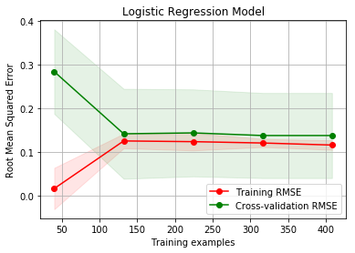

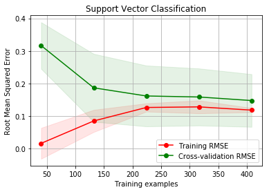

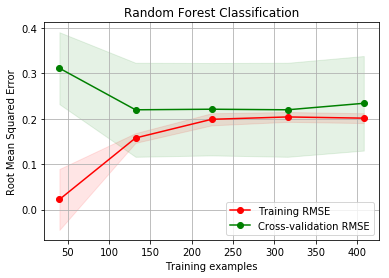

```python
## plot the learning curves
plot_curve_LogR()
plot_curve_SVC()
plot_curve_RF()
```

## MODEL SELECTION

To start the model selection process, I have cleaned up the testing data, to match the training set.

My choice of model was based on which model is the most accurate, and gives the best estimate out-of-sample accuracy. I used ROC curves and F1 score to compare the accuracy of the models.

### ROC Curves

The ROC curves for the models are shown below. Based on the curves all three models have great diagnostic abilities, with high area under the curve. The random forest model has the least performance on both the training data and test data. The logistic and SVC models have equal performance on the training data, but the logistic model performed slightly better on the test data.

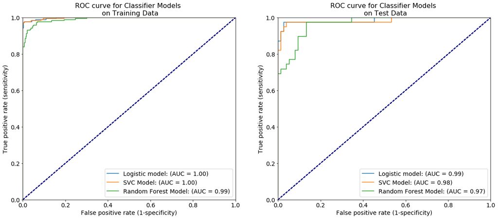

```python
## Compute score for plotting ROC curve
y_score_LogR_train = LogR.predict_proba(data_X)[:,1]
y_score_LogR_test = LogR.predict_proba(test_X)[:,1]
y_score_SVC_train = SVC_model.predict_proba(data_X)[:,1]
y_score_SVC_test = SVC_model.predict_proba(test_X)[:,1]
y_score_RF_train = RF.predict_proba(data_X)[:,1]
y_score_RF_test = RF.predict_proba(test_X)[:,1]



models_train=[y_score_LogR_train,y_score_SVC_train,y_score_RF_train]
models_test=[y_score_LogR_test,y_score_SVC_test,y_score_RF_test]


# plotting ROC curves
fig = plt.figure(figsize=(20, 8))
ax1 = fig.add_subplot(121)
for i in range(0,len(models_train)):
    fpr, tpr,thresholds= metrics.roc_curve(data_y,models_train[i], pos_label =1)
    ## Compute area under ROC curve
    area = auc(fpr, tpr)
    label=['Logistic model: (AUC = %0.2f)'% area, 'SVC Model: (AUC = %0.2f)'%area, 'Random Forest Model: (AUC = %0.2f)'%area]
    ax1.plot(fpr,tpr,label=label[i])
    ax1.plot([0,1], [0,1], color = 'navy', lw = 2, linestyle = '--')
ax1.set_xlim([0.0,1.0])
ax1.set_ylim([0.0,1.0])
ax1.set_title('ROC curve for Classifier Models \n on Training Data', fontsize = 16)
ax1.set_xlabel('False positive rate (1-specificity)', fontsize = 14)
ax1.set_ylabel('True positive rate (sensitivity)', fontsize = 14)
ax1.tick_params(labelsize=14)

ax1.legend(loc=4,fontsize = 14)


ax2 = fig.add_subplot(122)
for i in range(0,len(models_test)):
    fpr, tpr,thresholds= metrics.roc_curve(test_y,models_test[i], pos_label =1)
    ## Compute area under ROC curve
    area = auc(fpr, tpr)
    label=['Logistic model: (AUC = %0.2f)'% area, 'SVC Model: (AUC = %0.2f)'%area, 'Random Forest Model: (AUC = %0.2f)'%area]
    ax2.plot(fpr,tpr,label=label[i])
    ax2.plot([0,1], [0,1], color = 'navy', lw = 2, linestyle = '--')
ax2.set_xlim([0.0,1.0])
ax2.set_ylim([0.0,1.0])
ax2.set_title('ROC curve for Classifier Models \n on Test Data', fontsize = 16)
ax2.set_xlabel('False positive rate (1-specificity)', fontsize = 14)
ax2.set_ylabel('True positive rate (sensitivity)', fontsize = 14)
ax2.tick_params(labelsize=14)

ax2.legend(loc=4,fontsize = 14)

plt.show()
```

## F1 Scores

The plot below compares the F1 scores of the three models. The plot shows F1 score of test data versus F1 score of training data. The model that falls closer to the diagonal has a better estimate of out-of-sample accuracy. The SVC model has the highest F1 score for test data, and best estimate of out-of-sample accuracy.

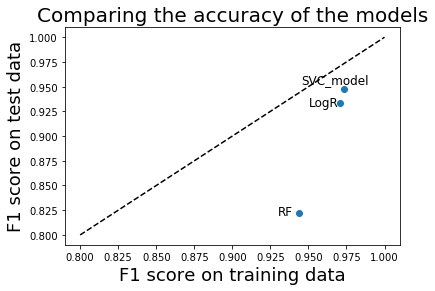

```python
data_y_pred_LogR = LogR.predict(data_X)
test_y_pred_LogR = LogR.predict(test_X)
a = f1_score(data_y, data_y_pred_LogR)
b = f1_score(test_y, test_y_pred_LogR)

data_y_pred_SVC = SVC_model.predict(data_X)
test_y_pred_SVC = SVC_model.predict(test_X)
c = f1_score(data_y, data_y_pred_SVC)
d = f1_score(test_y, test_y_pred_SVC)

data_y_pred_RF = RF.predict(data_X)
test_y_pred_RF = RF.predict(test_X)
e = f1_score(data_y, data_y_pred_RF)
f = f1_score(test_y, test_y_pred_RF)

F1_scores = pd.DataFrame([['Logistic Regression Model',a,b], ['Support Vector Classifier',c,d],
                         ['Random Forest',e,f]], columns = ('Model','F1 score on training data', 'F1 score on test data'))

fig, ax = plt.subplots()
ax.scatter(F1_scores['F1 score on training data'], F1_scores['F1 score on test data'])
ax.plot((0.8, 1), (0.8, 1), ls = "--", c="black")

ax.set_xlabel('F1 score on training data', fontsize = 18)
ax.set_ylabel('F1 score on test data', fontsize = 18)
ax.set_title('Comparing the accuracy of the models', fontsize = 20)

plt.text(0.95,0.93, 'LogR', fontsize = 12)
plt.text(0.945,0.954, 'SVC_model', fontsize = 12)
plt.text(0.93,0.82, 'RF', fontsize = 12)
plt.show()
```

Based on the analysis of the ROC curves, and F1 scores, my choice for a classification model is the SVC model.

## Feature Importance of the Support Vector Classifier Model

```python
## feature importance
importance = pd.DataFrame(SVC_model.coef_, index = ['coef'], columns = predictors).transpose()
print(importance.sort_values('coef', ascending = False))
```

```
                             coef
perimeter_worst          2.515786
radius_se                0.731713
concave points_worst     0.661039
texture_worst            0.644320
smoothness_worst         0.644277
symmetry_worst           0.504992
concavity_worst          0.454823
concave points_se        0.243194
compactness_se           0.082911
compactness_worst       -0.144669
smoothness_mean         -0.149657
compactness_mean        -0.156124
concavity_se            -0.165671
fractal_dimension_worst -0.179034
symmetry_mean           -0.259987
```

## Visualization of Classification Performance of Support Vector Classification Model

The plots below show just how well the model was able to classify the data.

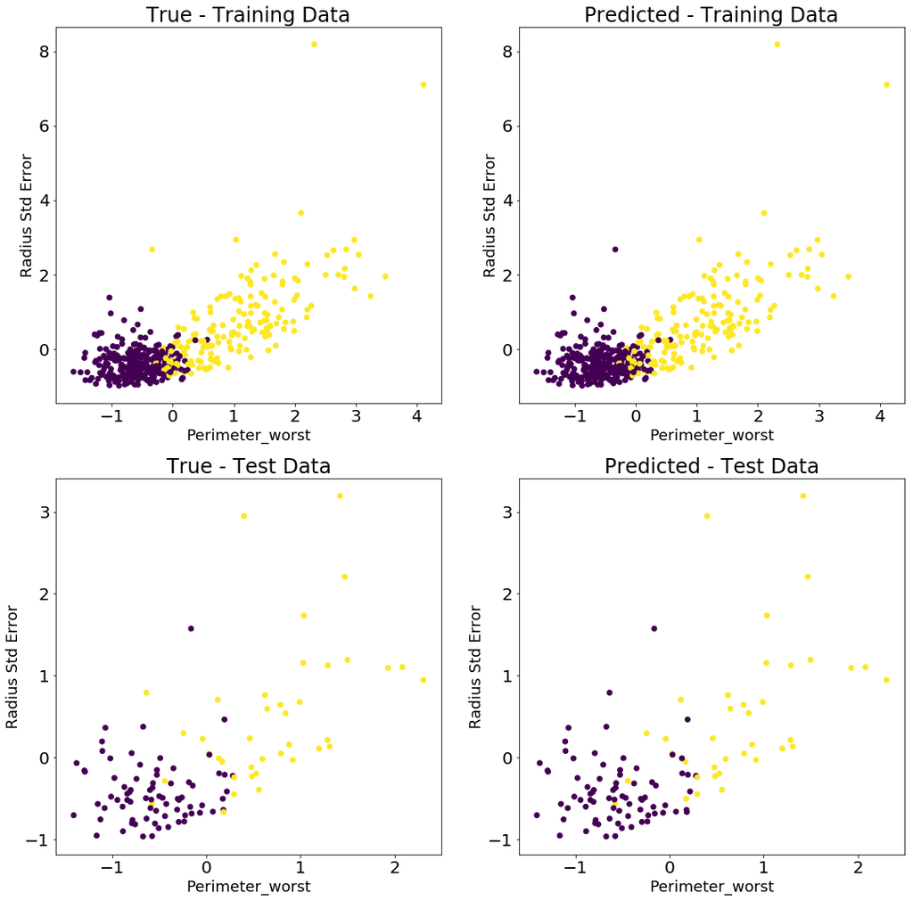

```python
fig = plt.figure(figsize=(18, 18))
ax = fig.add_subplot(221)
ax.scatter(x = data_X['perimeter_worst'],y = data_X['radius_se'], c = data_y)
ax.set_xlabel('Perimeter_worst', fontsize = 18)
ax.set_ylabel('Radius Std Error', fontsize = 18)
ax.set_title('True - Training Data', fontsize = 24)
ax.tick_params(labelsize=20)

ax2 = fig.add_subplot(222)
ax2.scatter(x = data_X['perimeter_worst'],y = data_X['radius_se'], c = data_y_pred_SVC)
ax2.set_xlabel('Perimeter_worst', fontsize = 18)
ax2.set_ylabel('Radius Std Error', fontsize = 18)
ax2.set_title('Predicted - Training Data', fontsize = 24)
ax2.tick_params(labelsize=20)

ax3 = fig.add_subplot(223)
ax3.scatter(x = test_X['perimeter_worst'],y = test_X['radius_se'], c = test_y)
ax3.set_xlabel('Perimeter_worst', fontsize = 18)
ax3.set_ylabel('Radius Std Error', fontsize = 18)
ax3.set_title('True - Test Data', fontsize = 24)
ax3.tick_params(labelsize=20)

ax4 = fig.add_subplot(224)
ax4.scatter(x = test_X['perimeter_worst'],y = test_X['radius_se'], c = test_y_pred_SVC)
ax4.set_xlabel('Perimeter_worst', fontsize = 18)
ax4.set_ylabel('Radius Std Error', fontsize = 18)
ax4.set_title('Predicted - Test Data', fontsize = 24)
ax4.tick_params(labelsize=20)


plt.show()
```

## Classification Report

### For Training Data

```python
target_names = ['Benign', 'Malignant']
print(classification_report(data_y, data_y_pred_SVC, target_names=target_names))
```

```
             precision    recall  f1-score   support

     Benign       0.97      1.00      0.98       282
  Malignant       1.00      0.95      0.97       173

avg / total       0.98      0.98      0.98       455
```

### For Test Data

```python
print(classification_report(test_y, test_y_pred_SVC, target_names=target_names))
```

```
             precision    recall  f1-score   support

     Benign       0.96      0.99      0.97        75
  Malignant       0.97      0.92      0.95        39

avg / total       0.97      0.96      0.96       114
```